# Introduction to Machine Learning

Session 1: Foundations, Nearest Neighbors & Linear Prediction

David Picard

2026-09-21

# Welcome

## Session 1: Agenda

8:30–11:35 · 185 min

| Time | Block |
| --- | --- |
| 8:30–9:10 | What is ML? · Formal setting · ERM |
| 9:10–9:15 | ⚡ Exercise 1: ERM failure |
| 9:15–9:25 | Generalization & PAC bound |
| 9:25–10:00 | 1-NN & *k*-NN (incl. Cover–Hart theorem) |
| 10:00–10:10 | Model selection (cross-validation, test set) |
| 10:10–10:20 | ☕ Break |
| 10:20–10:35 | PAC-learnability · Bridge to Chapter 2 |
| 10:35–11:05 | PCA · Bluebell examples & reconstruction |
| 11:05–11:20 | Linear regression (incl. interactive fit) |
| 11:20–11:30 | 💻 Coding lab: *k*-NN + cross-validation |
| 11:30–11:35 | Wrap-up & next session |

## What is Machine Learning?

> Le savant n’étudie pas la nature parce que cela est utile ; il l’étudie parce qu’il y prend plaisir et il y prend plaisir parce qu’elle est belle.

> — Henri Poincaré, *Science et Méthode* (1908)

> It is that the sciences do not try to explain, they hardly even try to interpret, they mainly make models. […] The justification of such a mathematical construct is solely and precisely that it is expected to work.

> — John von Neumann, *Method in the Physical Sciences* (1955)

## An informal definition

**Machine Learning** is the art of automating the creation of models from data such that they make accurate predictions.

- No requirement to *understand* or *explain*, only to predict accurately
- The model comes from **data**, not human intuition
- Tension between *data* and *human intuition* (inductive bias) will recur throughout the course

# Formal Setting

0:10–0:25 · 15 min

## Random variables, predictors, loss

Consider a pair of random variables $(x, y)$ with unknown joint probability $P(x, y)$. We seek $f$ such that $f(x) \approx y$.

**0-1 loss.** For a prediction $f(x)$ and target $y$,
$$\ell(f(x), y) = 0 \text{ iff } f(x) = y, \text{ else } 1.$$

## True risk & Bayes error

**True risk.** $\displaystyle \mathcal{R}_f = \mathbb{E}[\ell(f(x), y)] = \int \ell(f(x), y)\, dP(x, y)$

**Bayes error.** $\displaystyle \mathcal{R}_{\min} = \mathbb{E}\big[\ell(\arg\max_z P(x, z), y)\big]$, the irreducible error.

- $\mathcal{R}_f$ is **not computable**: $P(x,y)$ is unknown
- $\mathcal{R}_{\min}$ is the best *any* predictor can do

## Determinism proposition

$\mathcal{R}_{\min} = 0$ if and only if the process $x \mapsto y$ is deterministic, i.e. $\forall z \neq y,\ P(x, z) = 0$.

*Proof sketch:* split the expectation on whether $\arg\max_z P(x,z) = y$; the non-deterministic case forces a strictly positive integral unless $P(x,z)=0$ for all $z \neq y$.

# Empirical Risk Minimization

0:25–0:40 · 15 min

## From an abstract risk to a computable one

Given a dataset $\mathcal{A} = \{(x_i, y_i)\}_{i \leq n}$ sampled i.i.d. from $P(x,y)$:

**Empirical risk.** $\displaystyle \hat{\mathcal{R}}_{\mathcal{A}}(f_\theta) = \frac{1}{n}\sum_{(x,y)\in\mathcal{A}} \ell(f_\theta(x), y)$

The empirical risk is an **unbiased and consistent** estimator of the true risk: $\mathbb{E}[\hat{\mathcal{R}}_{\mathcal{A}}(f_\theta)] = \mathcal{R}_f$ and $\hat{\mathcal{R}}_{\mathcal{A}}(f_\theta) \to \mathcal{R}_f$ as $n \to \infty$.

## The ERM principle

**Empirical Risk Minimization (ERM).** Given $\{f_\theta\}_{\theta \in \Theta}$ and $\mathcal{A}$, return $f_{\theta^\star}$ with
$$\theta^\star = \arg\min_{\theta \in \Theta} \hat{\mathcal{R}}_{\mathcal{A}}(f_\theta).$$

- Purely data-driven: only assumes $P(x,y)$ exists and can be sampled
- Guaranteed in the limit to match the true risk of the chosen $f_\theta$

## Inductive bias

**Inductive bias.** The set of assumptions, prior knowledge, or preferences that a learning algorithm uses *in addition to* data.

- Restricting $\Theta$ (the search space) is already an inductive bias
- Strictly speaking: no ML algorithm is bias-free (choosing $x, y$ already assumes something), but we reserve the term for *strong* constraints
- This trade-off (data vs. bias) returns in every chapter

# Exercise 1

0:40–0:45 · 5 min

## ⚡ ERM failure example

Construct a toy hypothesis class and dataset where the empirical risk is zero but the true risk is large. Make the overfitting gap explicit and explain which assumption of ERM it violates.

*Format: 4 min work + 1 min share-out.*

# Generalization & the PAC Bound

0:45–0:55 · 10 min

## The generalization gap

**Generalization gap.** $\displaystyle \Gamma_f = \mathcal{R}_f - \hat{\mathcal{R}}_{\mathcal{A}}(f)$.

- Abstract (uses the incomputable $\mathcal{R}_f$) but central theoretically
- Goal: bound $\Gamma_f$ using only the size of $\mathcal{A}$ (and maybe the algorithm’s properties)

## A first PAC bound

Under the **realizability assumption** ($\exists h^\star \in \mathcal{H},\ \mathcal{R}_{h^\star} = 0$):

**PAC generalization bound.** For finite $\mathcal{H}$, $\delta, \varepsilon > 0$, and $m \geq \frac{\ln(|\mathcal{H}|/\delta)}{\varepsilon}$, ERM on $m$ samples yields $h_{\mathcal{A}}$ with
$$P[\Gamma_{h_{\mathcal{A}}} > \varepsilon] \leq \delta.$$

- Union bound over “misleading” datasets (proof in the book)
- Numeric reality check: $64\times64$ RGB template predictor $\Rightarrow |\mathcal{H}| = 2^{64\times64\times24}$, needs $m \approx 6.8$M samples for $1\%$ error at $99\%$ confidence, **already impractical**

# 1-Nearest Neighbor

0:55–1:15 · 20 min

## The nearest neighbor rule

Assumption: $\mathcal{X}$ is endowed with a distance $\|x - x'\|$ and nearby $x$ share the same $y$.

**1-NN prediction.** Given $\mathcal{A} = \{(x_i,y_i)\}$ and query $x$: compute $\mathbf{d} = [\|x-x_1\|, \dots, \|x-x_n\|]$, find $i = \arg\min_j \mathbf{d}_j$, return $\hat{y} = y_i$.

- “Learning” = memorizing $\mathcal{A}$, the model **is** the training set
- Decision regions are the **Voronoi cells** of $\mathcal{A}$, colored by class

## Voronoi decision regions

[interactive chart not shown]

*1-NN on the 2D toy example of the book*

## Cover–Hart generalization theorem

**Nearest-neighbor convergence.** Under mild continuity conditions on $p$, the nearest neighbor $x_n'$ of $x$ among $n$ i.i.d. samples converges to $x$ almost surely as $n \to \infty$.

**1-NN generalization (Cover & Hart, 1967).** As $n \to \infty$,
$$\mathcal{R}^\star \leq \mathcal{R} \leq 2\mathcal{R}^\star(1 - \mathcal{R}^\star),$$
with $\mathcal{R}^\star$ the Bayes error.

## Cover–Hart, proof sketch

- Pointwise error $r(x, x_n') \to r(x) = 2p_1(x)(1-p_1(x))$ a.s. (using the convergence lemma + continuity)
- Lower bound: $r^\star(x) \le 1/2 \Rightarrow \mathcal{R} \geq \mathbb{E}[r^\star(x)] \geq \mathcal{R}^\star$
- Upper bound: expand $\mathcal{R} = 2\mathcal{R}^\star - 2\mathbb{E}[r^\star(x)^2]$, use $\mathrm{Var}(r^\star(x)) \geq 0$
- **Takeaway:** if the process is deterministic ($\mathcal{R}^\star = 0$), 1-NN is asymptotically perfect, “learning = memorizing” in this limit (link to representer theorems, later in the course)

# k-Nearest Neighbor

1:15–1:30 · 15 min

## From 1 to *k* neighbors

$k$-NN prediction. Rank samples by distance to $x$, take the $k$ nearest $\mathcal{N}$, return the majority class $\arg\max_j \sum_{(x_i,y_i)\in\mathcal{N}} \delta_{y_i,j}$.

- More neighbors $\Rightarrow$ smoother, more robust decision boundary
- Isolated / mislabeled points contribute less as $k$ grows
- Can have strange non-local effect

## Effect of *k*

[interactive chart not shown]

k = 1

*$k$-NN on the same 2D toy dataset, for variable $k$*

## Choosing *k*

- **Not** an ERM problem: it compares *across* families, and $k=1$ always has $\hat{\mathcal{R}}_{\mathcal{A}} = 0$, it always “wins” trivially
- $\Rightarrow$ use **cross-validation** to pick $k$ (= another dataset)
- Ties (e.g. $k=1$ vs $k=21$) broken by simplicity / robustness to outliers
- Using another dataset to select a model **biases its evaluation**

# Model Selection

1:30–1:40 · 10 min

## Cross-validation

How do we select the right model?

- ERM $\Rightarrow$ consumes data to *optimize* a model
- *Selecting* a model (hyper parameters) also consumes data
- **Data used for one cannot be used for the other**

$K$-fold CV. Split $\mathcal{A}$ into $K$ folds; for each fold, train on the rest, validate on it; average the $K$ errors.

**Random-split CV.** Repeat $K$ times: random train/validation split with ratio $r$; average the errors. (Controls training-set size, reuses samples.)

## Leave-one-out & the test set

What about the performances of the model?

- **Leave-one-out (LOO)**: $K = |\mathcal{A}|$, costly but informative, has a dedicated generalization bound (uniform stability, Bousquet & Elisseeff 2002)
- Using validation data for model selection **contaminates** that estimate
- $\Rightarrow$ three disjoint sets: **train** (ERM) / **validation** (model selection, hyper-parameters) / **test** (final estimate)
- Reusing data across roles $\Rightarrow$ **overfitting**

# Break

1:40–1:50 · 10 min

## ☕ 10-minute break

Back at **10:20** for PAC-learnability and Chapter 2.

# PAC-Learnability

1:50–2:00 · 10 min

## Definition

**PAC-learnability.** $\mathcal{H}$ is PAC-learnable if for every $\varepsilon, \delta > 0$ and every distribution $\mathcal{D}$, there exists an algorithm $A$ and sample complexity $m(\varepsilon,\delta,\mathcal{D})$ such that running $A$ on $m$ samples returns $h$ with $\mathcal{R}_h \leq \mathcal{R}_{h^\star} + \varepsilon$ with probability $1-\delta$.

- Two questions: **what** is learnable, and **how efficiently** (sample complexity vs. rates)

## Fundamental theorem of PAC learning

**(Simplified.)** For $\mathcal{H} \subseteq \{\mathcal{X}\to\{0,1\}\}$ under the 0-1 loss, the following are equivalent:

1. $\mathcal{H}$ has the uniform convergence property
2. $\mathcal{H}$ is PAC learnable
3. Any ERM rule is a successful PAC learner for $\mathcal{H}$
4. $\mathcal{H}$ has finite VC dimension
- VC dimension is formally introduced in Chapter 4, for now, *learnability, ERM success, and a finite “capacity” measure all coincide*
- No proof today (needs VC dimension + uniform convergence machinery)

# Chapter 2 - Preview

2:00–2:05 · 5 min

## From abstract risk to concrete models

- So far: *any* $f_\theta$, abstract risk, generic guarantees
- Now: a first real family, **linear predictors** $h(x) = \langle w, x\rangle$
- Running task for the rest of the course: the **Bluebell dataset**, 1800 64² px images, classified into 12 flower classes

# Principal Component Analysis

2:05–2:35 · 30 min

## Motivation: compression & reconstruction

Is there a low-dimensional subspace of $\mathcal{X}$ that captures almost all the information in $x \in \mathcal{X}$?

Given $\mathcal{A} = \{x_i \in \mathbb{R}^d\}$, find $w \in \mathbb{R}^{d}$, $\|w\|^2=1$, minimizing the **empirical reconstruction risk**
$$\mathcal{L}(w) = \frac{1}{n}\sum_i \|x_i - ww^\top x_i\|^2.$$

## From reconstruction to an eigenproblem

Equivalent to $\max_w w^\top \Sigma w$ s.t. $\|w\|^2=1$, with $\Sigma = \frac1n\sum_i x_i x_i^\top$.

The solution is the eigenvector of $\Sigma$ with the **largest eigenvalue** (Lagrangian $\Rightarrow \Sigma w = \lambda w$; or Rayleigh quotient argument).

- Subtract the mean first $\Rightarrow \Sigma$ becomes the empirical **covariance** $\Rightarrow$ this is PCA: the direction of maximal variance
- Higher target dimension: iterate on the residuals

## PCA in action

[interactive chart not shown]

## The Bluebell dataset

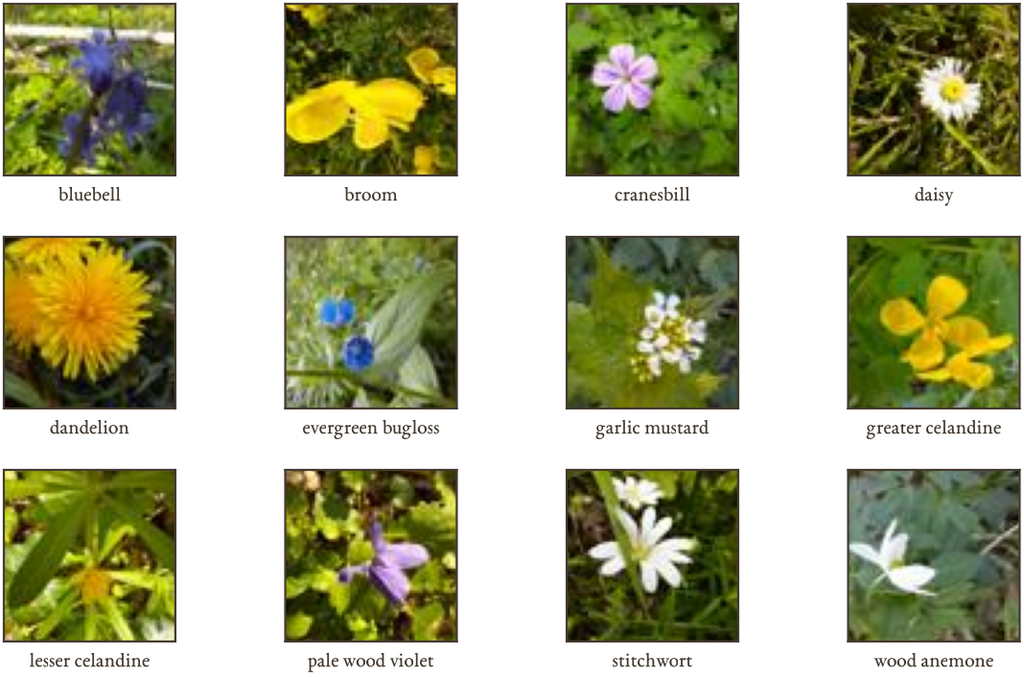

One example from each of the 12 Bluebell classes

## Principal components of Bluebell

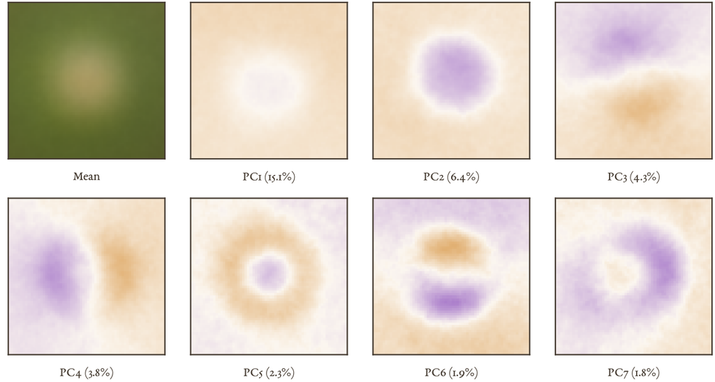

Mean and the first 7 principal directions of the (pixel-space) Bluebell dataset. Percentages: fraction of total variance explained.

*PC1 alone already carries ~15% of the variance (roughly the “green background vs. flower blob” contrast)*

## Bluebell reconstruction

k = 5

*Each reconstruction is $\hat{x} = \mu + \sum_{i \leq k} \text{coeff}_i \cdot \text{component}_i$, up to 64 principal directions*

# Linear Regression

2:35–2:50 · 15 min

## Setup & loss

Supervised version: $\mathcal{A} = \{(x_i, y_i)\}$, $x_i \in \mathbb{R}^d$, $y_i \in \mathbb{R}$.
$$\mathcal{L}(w) = \frac1n \sum_i \|y_i - w^\top x_i\|^2$$

Empirical risk: reconstruction of $y$ from linear projection of $x$

## Closed-form solution

Matrix form: $\mathcal{L}(w) = \|Y - Xw\|^2$. Setting $\partial \mathcal{L}/\partial w = 0$:

**Moore–Penrose solution.** If $X^\top X$ is invertible,
$$w = (X^\top X)^{-1} X^\top Y.$$

- Two practical issues: (1) $X^\top X$ must be full rank, PCA can help by compressing first; (2) inverting is expensive at scale ($64\times64\times3$ Bluebell images $\approx 12$k dims, inversion has $d^3$ complexity)
- $\Rightarrow$ SGD as a fallback

## Linear regression as a classifier

[interactive chart not shown]

*Same synthetic dataset as the 1-NN/*$k$*-NN slides. Regress the label mapped to $t=\pm1$ on $(x_1,x_2)$ with a bias column, color the background by $\mathrm{sign}(w^\top x + b)$, and draw that zero level set (solid bordeaux)*

# Coding Lab

2:50–3:00 · 10 min

## 💻 *k*-NN + cross-validation

1. Implement `predict(A, x, k)` for $k$-NN (vectorized distances, `knearestneighbor.py` as a reference/starting point).
2. On the provided 2D synthetic dataset, run **5-fold CV** for $k \in \{1, 3, 5, 7, 11, 15, 21\}$.
3. Plot mean $\pm$ std CV error vs. $k$. Pick a $k$ and justify your choice *without* looking at the held-out test set.
4. Compare to the $1$-NN / $21$-NN tie discussed earlier

*Format: individual or pairs, work at own pace; walk the room for questions.*

# Wrap-up

3:00–3:05 · 5 min

## Recap

- ML $=$ ERM on data, but ERM alone doesn’t tell us how well we’ll generalize $\Rightarrow$ generalization bounds, cross-validation, test sets
- 1-NN / $k$-NN: the simplest non-parametric learners, with real generalization guarantees (Cover–Hart)
- PCA and linear regression: first linear models

## Next session

- Finish **Chapter 2**: linear classification, generalized linear models (polynomial & periodic maps), regularization (LASSO, Ridge)
- All of **Chapter 3** Kernels and representer theorems, SVMs.